# IE6600_Sec06_Group08_Hackathon

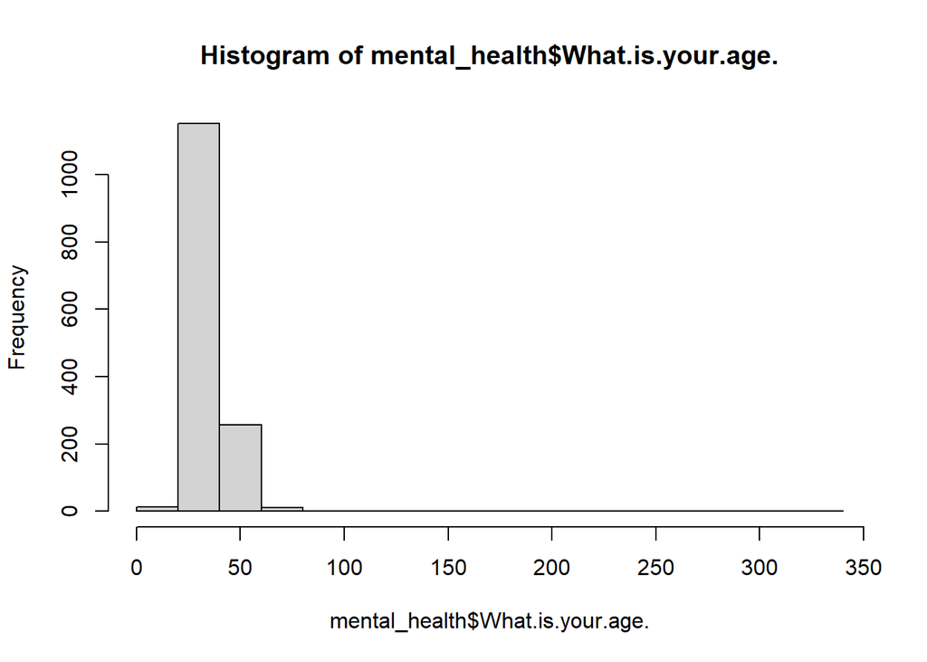

```r
hist(mental_health$What.is.your.age.)
```

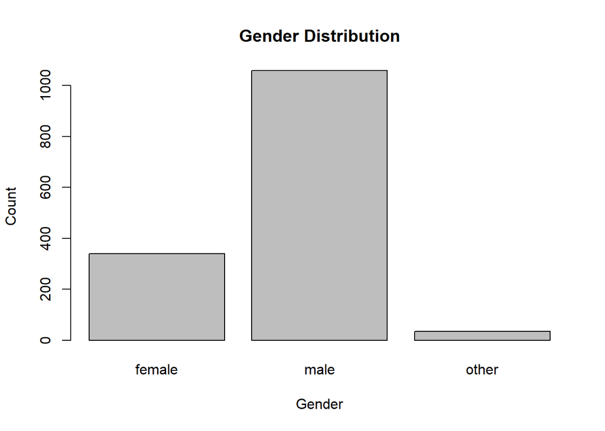

```r
library(ggplot2)
barplot(table(mental_health$What.is.your.gender.), main = "Gender Distribution", xlab = "Gender", ylab = "Count")
```

```r
mental_health$What.is.your.gender. <- str_to_lower(mental_health$What.is.your.gender., locale = "en")
unique(mental_health$What.is.your.gender.)
```

```
## [1] "male"   "female" "other"
```

```r
gender_distribution <- mental_health%>%
  group_by(What.is.your.gender.)%>%
  summarise(count_gender = n())
gender_distribution
```

| What.is.your.gender. | count_gender |
| --- | --- |
| female | 340 |
| male | 1059 |
| other | 34 |

```r
# The above code is used to obtain the summary of the data for studying. Also, a histogram is created to visualize the distribution of age in the data.
```

##On studying the data, we see that there are a few unusual values in the Age variable, i.e the maximum age being 323. To get a better picture of the data, we have filtered for ages greater than 16 and lesser than 70.

```r
mental_health_1 <- mental_health[!(mental_health$What.is.your.age. > 70 | mental_health$What.is.your.age. <16), ]
summary(mental_health_1$What.is.your.age.)
```

```
##    Min. 1st Qu.  Median    Mean 3rd Qu.    Max.
##   17.00   28.00   33.00   34.05   38.25   70.00
```

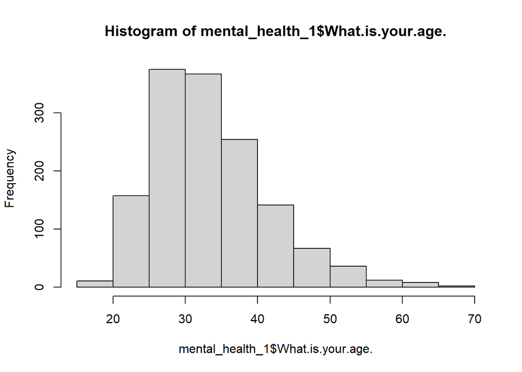

```r
hist(mental_health_1$What.is.your.age.)
```

```r
# Age is filtered for including values only between 16 and 70. Distribution can be seen in the below histogram
```

#Checking the dataframe for any missing values, changing blank cells to N/A

```r
#check for missing values

  df1 <- mental_health_1 %>% filter( mental_health_1$self_employed == 1)
  df1
```

[output not shown]

[output cut: 276 more lines]

```r
  unique(mental_health_1$self_employed)
```

```
## [1] 0 1
```

```r
#change blank cells to NA
mental_health_1 <- mental_health_1 %>%
  na_if("")

unique(mental_health_1$company_size)
```

```
## [1] 26-100         25-Jun         <NA>           More than 1000 100-500
## [6] 500-1000       5-Jan
## Levels:  100-500 25-Jun 26-100 5-Jan 500-1000 More than 1000
```

```r
# The data is cleaned to convert the missing values to 'NA' using this code chunk.
```

#Theme1 - Understanding the population and demographic who responded to this survey

#Q1 - Are Mental health issues more prevalent in employed people v/s people who are self employed

```r
#self vs company

mental_health_1$self_employed <- gsub("0" , "Employed in a Company", mental_health_1$self_employed)
mental_health_1$self_employed <- gsub("1" , "Self-Employed", mental_health_1$self_employed)

library(ggplot2)
unique(mental_health_1$Do.you.currently.have.a.mental.health.disorder.)
```

```
## [1] "No"    "Yes"   "Maybe"
```

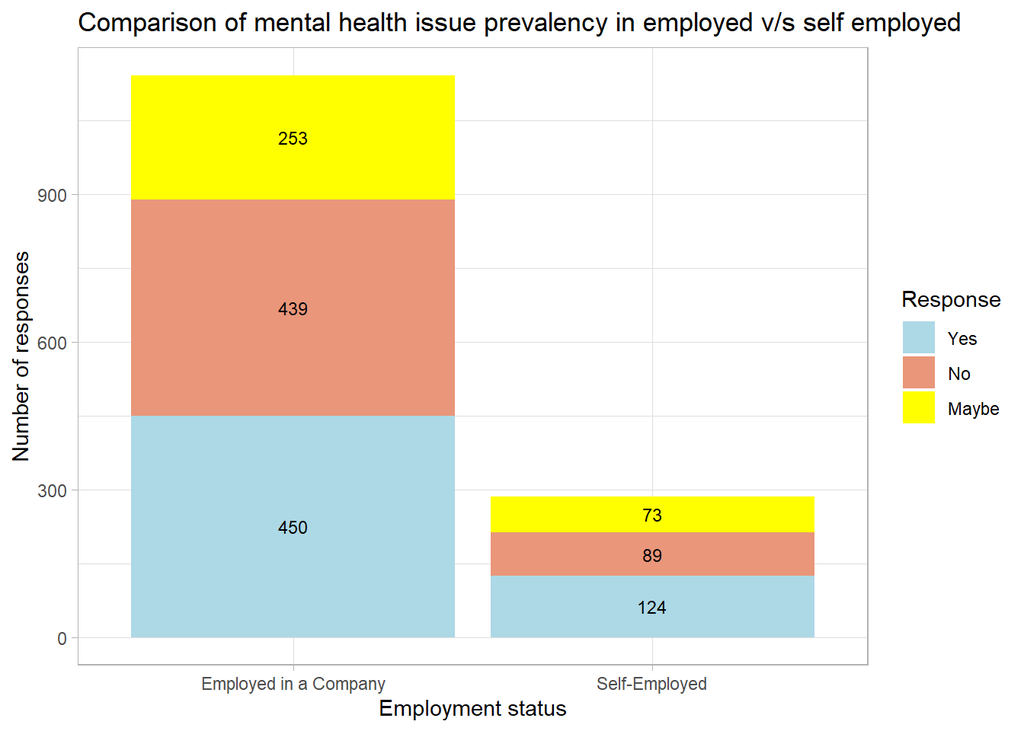

```r
df1 <- mental_health_1 %>%
  group_by(self_employed, Do.you.currently.have.a.mental.health.disorder.) %>%
  summarise(count = n())

#plot1
p1 <- ggplot(df1,aes(x = as.factor(self_employed), y = count, label = count, fill = Do.you.currently.have.a.mental.health.disorder.)) +
  geom_bar(stat = "identity") +
  geom_text(size = 3, position = position_stack(vjust = 0.5)) +
  scale_fill_manual(name="Response", values = c("Yes" = "Light Blue", "No" = "Darksalmon", "Maybe" = "Yellow")) +       ggtitle("Comparison of mental health issue prevalency in employed v/s self employed") +
  labs(y="Number of responses", x = "Employment status") +
  theme_light()

p1
```

```r
# In this code, column with employment type data and the column that has mental health data are aggregated to find the count of people responses for each group and visualized using a stacked bar chart.
```

#Q2 - What is the distribution of gender in the survey. Is there any impact of gender on mental health issues in technology?

```r
#plot2
#TOTAL NUMBER OF MALE AND FEMALE
df2 <- mental_health_1 %>%
  group_by(What.is.your.gender.) %>%
  summarise(count1 = n())
df2
```

| What.is.your.gender. | count1 |
| --- | --- |
| female | 339 |
| male | 1056 |
| other | 33 |

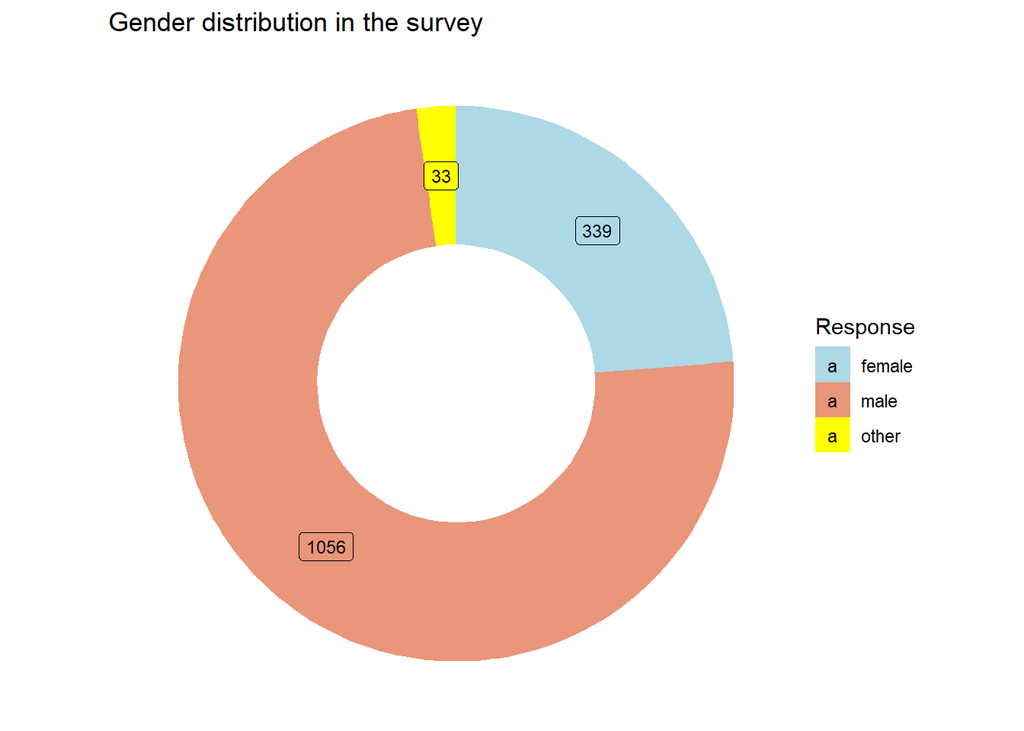

```r
df2$ymax=cumsum(df2$count1/100)
df2$ymin=c(0,head(df2$ymax,n=-1))
df2$labelPosition <- (df2$ymax + df2$ymin) / 2
ggplot(df2, aes(ymax=ymax, ymin=ymin, xmax=4, xmin=3, fill=What.is.your.gender.)) +
     geom_rect() +
     coord_polar(theta="y") +
     xlim(c(2, 4))    +
  theme_void() +
  geom_label( x=3.5, aes(y=labelPosition, label=count1), size=3) + scale_fill_manual(name = "Response", values = c("female" = "Light Blue", "male" = "Darksalmon", "other" = "Yellow")) +ggtitle("Gender distribution in the survey")
```

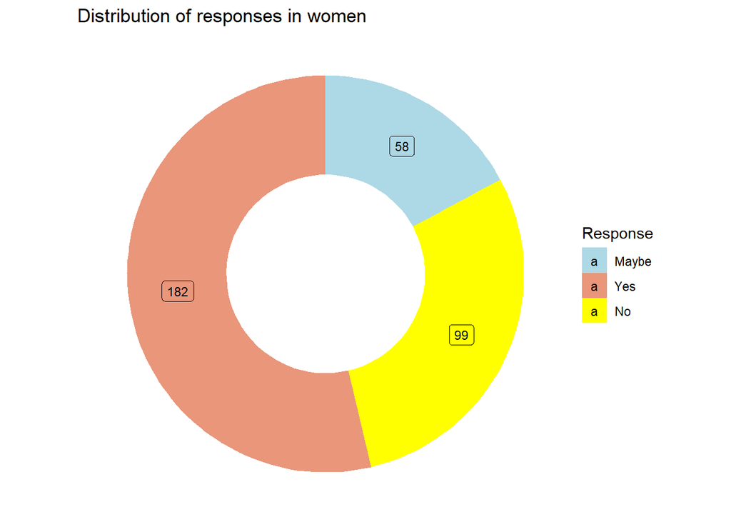

```r
#WOMEN only
df2women <- mental_health_1 %>%
  filter(What.is.your.gender.=="female")%>%
  group_by(Do.you.currently.have.a.mental.health.disorder.) %>%
  summarise(count1 = n())

df2women$ymax=cumsum(df2women$count1/100)
df2women$ymin=c(0,head(df2women$ymax,n=-1))
df2women$labelPosition <- (df2women$ymax + df2women$ymin) / 2
pwomen<- ggplot(df2women, aes(ymax=ymax, ymin=ymin, xmax=4, xmin=3, fill=Do.you.currently.have.a.mental.health.disorder.)) +
     geom_rect() +
     coord_polar(theta="y") +
     xlim(c(2, 4))    +
  theme_void() +
  geom_label( x=3.5, aes(y=labelPosition, label=count1), size=3) + scale_fill_manual(name= "Response", values = c("Maybe" = "Light Blue", "Yes" = "Darksalmon", "No" = "Yellow"))+ggtitle("Distribution of responses in women")
pwomen
```

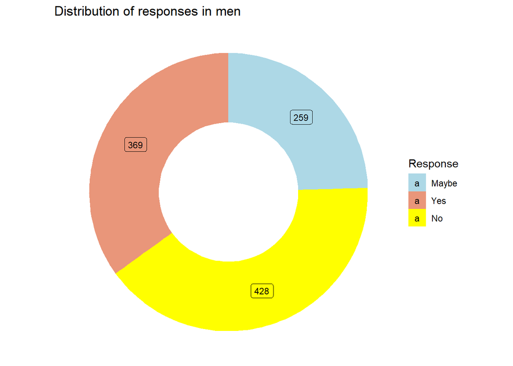

```r
#Men
df2men <- mental_health_1 %>%
  filter(What.is.your.gender.=="male")%>%
  group_by(Do.you.currently.have.a.mental.health.disorder.) %>%
  summarise(count1 = n())
df2men$ymax=cumsum(df2men$count1/100)
df2men$ymin=c(0,head(df2men$ymax,n=-1))
df2men$labelPosition <- (df2men$ymax + df2men$ymin) / 2
pmen<-ggplot(df2men, aes(ymax=ymax, ymin=ymin, xmax=4, xmin=3, fill=Do.you.currently.have.a.mental.health.disorder.)) +
     geom_rect() +
     coord_polar(theta="y") +
     xlim(c(2, 4))    +
  theme_void() +
  geom_label( x=3.5, aes(y=labelPosition, label=count1), size=3) + scale_fill_manual(name = "Response", values = c("Maybe" = "Light Blue", "Yes" = "Darksalmon", "No" = "Yellow"))+ggtitle("Distribution of responses in men")
pmen
```

```r
# Column that containing the gender information is aggregated to find the distribution of people overall (donut-chart-1), and later coupled with mental health responses to find the distribution (donut-chart-2&3)
```

#Q3 - Is mental illness dependent on the designation of the employee?

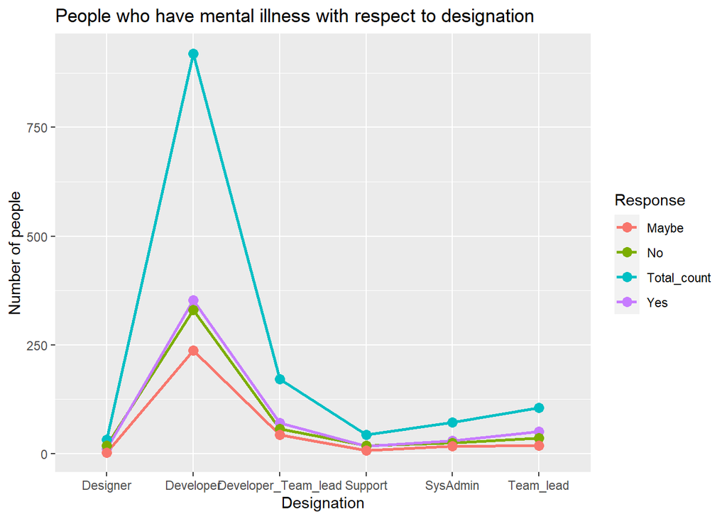

```r
library(readr)

a <- mental_health_1 %>%
  group_by(Which.of.the.following.best.describes.your.work.position.) %>%
  summarise(c=n()) %>%
  arrange(desc(c)) # Overall designation distribution from the dataset

Developer <- 0
Developer_Team_lead <- 0
Team_lead <- 0
SysAdmin <- 0
Support <- 0
Designer<- 0

for (i in 1:nrow(mental_health_1))
  if (str_detect(mental_health$Which.of.the.following.best.describes.your.work.position.[i],"Developer") == TRUE) {
    Developer <- Developer + 1
    if (str_detect(mental_health$Which.of.the.following.best.describes.your.work.position.[i],"Team Lead|Supervisor") == TRUE) {
      Developer_Team_lead <- Developer_Team_lead + 1
    }
  } else if (str_detect(mental_health$Which.of.the.following.best.describes.your.work.position.[i],"Team Lead|Supervisor") == TRUE) {
    Team_lead <- Team_lead + 1
  } else if (str_detect(mental_health$Which.of.the.following.best.describes.your.work.position.[i],"SysAdmin") == TRUE) {
    SysAdmin <- SysAdmin + 1
  } else if (str_detect(mental_health$Which.of.the.following.best.describes.your.work.position.[i],"Support") == TRUE) {
    Support <- Support + 1
  } else if (str_detect(mental_health$Which.of.the.following.best.describes.your.work.position.[i],"Designer") == TRUE) {
    Designer <- Designer + 1
  }

occup_t <- data.frame(Designation = c("Developer","Developer_Team_lead","Team_lead","SysAdmin","Support","Designer"),
  Total_count = c(Developer,Developer_Team_lead,Team_lead,SysAdmin,Support,Designer))

# The above for loop computes the total number of people from above designations that took part in the survey

# People that work under the below work designations are considered from the dataset

Developer <- 0
Developer_Team_lead <- 0
Team_lead <- 0
SysAdmin <- 0
Support <- 0
Designer<- 0

for (i in 1:nrow(mental_health_1))
  if (mental_health_1$Do.you.currently.have.a.mental.health.disorder.[i] == "Yes") {
  if (str_detect(mental_health$Which.of.the.following.best.describes.your.work.position.[i],"Developer") == TRUE) {
    Developer <- Developer + 1
    if (str_detect(mental_health$Which.of.the.following.best.describes.your.work.position.[i],"Team Lead|Supervisor") == TRUE) {
      Developer_Team_lead <- Developer_Team_lead + 1
    }
  } else if (str_detect(mental_health$Which.of.the.following.best.describes.your.work.position.[i],"Team Lead|Supervisor") == TRUE) {
    Team_lead <- Team_lead + 1
  } else if (str_detect(mental_health$Which.of.the.following.best.describes.your.work.position.[i],"SysAdmin") == TRUE) {
    SysAdmin <- SysAdmin + 1
  } else if (str_detect(mental_health$Which.of.the.following.best.describes.your.work.position.[i],"Support") == TRUE) {
    Support <- Support + 1
  } else if (str_detect(mental_health$Which.of.the.following.best.describes.your.work.position.[i],"Designer") == TRUE) {
    Designer <- Designer + 1
  }
  }



occup_1 <- data.frame(Designation = c("Developer","Developer_Team_lead","Team_lead","SysAdmin","Support","Designer"),
                      Yes = c(Developer,Developer_Team_lead,Team_lead,SysAdmin,Support,Designer))

# The above for loop computes the people from a given designation that responded 'Yes' for mental illness and stores in the occup_1 dataframe

Developer <- 0
Developer_Team_lead <- 0
Team_lead <- 0
SysAdmin <- 0
Support <- 0
Designer<- 0

for (i in 1:nrow(mental_health_1))
  if (mental_health_1$Do.you.currently.have.a.mental.health.disorder.[i] == "No") {
    if (str_detect(mental_health$Which.of.the.following.best.describes.your.work.position.[i],"Developer") == TRUE) {
      Developer <- Developer + 1
      if (str_detect(mental_health$Which.of.the.following.best.describes.your.work.position.[i],"Team Lead|Supervisor") == TRUE) {
        Developer_Team_lead <- Developer_Team_lead + 1
      }
    } else if (str_detect(mental_health$Which.of.the.following.best.describes.your.work.position.[i],"Team Lead|Supervisor") == TRUE) {
      Team_lead <- Team_lead + 1
    } else if (str_detect(mental_health$Which.of.the.following.best.describes.your.work.position.[i],"SysAdmin") == TRUE) {
      SysAdmin <- SysAdmin + 1
    } else if (str_detect(mental_health$Which.of.the.following.best.describes.your.work.position.[i],"Support") == TRUE) {
      Support <- Support + 1
    } else if (str_detect(mental_health$Which.of.the.following.best.describes.your.work.position.[i],"Designer") == TRUE) {
      Designer <- Designer + 1
    }
  }

occup_2 <- data.frame(Designation = c("Developer","Developer_Team_lead","Team_lead","SysAdmin","Support","Designer"),
                      No = c(Developer,Developer_Team_lead,Team_lead,SysAdmin,Support,Designer))

# The above for loop computes the people from a given designation that responded 'No' for mental illness and stores in the occup_2 dataframe

Developer <- 0
Developer_Team_lead <- 0
Team_lead <- 0
SysAdmin <- 0
Support <- 0
Designer<- 0

for (i in 1:nrow(mental_health_1))
  if (mental_health_1$Do.you.currently.have.a.mental.health.disorder.[i] == "Maybe") {
    if (str_detect(mental_health$Which.of.the.following.best.describes.your.work.position.[i],"Developer") == TRUE) {
      Developer <- Developer + 1
      if (str_detect(mental_health$Which.of.the.following.best.describes.your.work.position.[i],"Team Lead|Supervisor") == TRUE) {
        Developer_Team_lead <- Developer_Team_lead + 1
      }
    } else if (str_detect(mental_health$Which.of.the.following.best.describes.your.work.position.[i],"Team Lead|Supervisor") == TRUE) {
      Team_lead <- Team_lead + 1
    } else if (str_detect(mental_health$Which.of.the.following.best.describes.your.work.position.[i],"SysAdmin") == TRUE) {
      SysAdmin <- SysAdmin + 1
    } else if (str_detect(mental_health$Which.of.the.following.best.describes.your.work.position.[i],"Support") == TRUE) {
      Support <- Support + 1
    } else if (str_detect(mental_health$Which.of.the.following.best.describes.your.work.position.[i],"Designer") == TRUE) {
      Designer <- Designer + 1
    }
  }

occup_3 <- data.frame(Designation = c("Developer","Developer_Team_lead","Team_lead","SysAdmin","Support","Designer"),
                      Maybe = c(Developer,Developer_Team_lead,Team_lead,SysAdmin,Support,Designer))

# The above for loop computes the people from a given designation that responded 'Maybe' for mental illness and stores in the occup_3 dataframe

occup_f1 <- merge(occup_t,occup_1,by = "Designation")
occup_f2 <- merge(occup_2,occup_3,by = "Designation")

occup_f <-  merge(occup_f1,occup_f2,by = "Designation")

occup_f <- occup_f %>%
  pivot_longer(cols = Total_count:Maybe, names_to = "Response", values_to = "Count")

ggplot(occup_f, aes(Designation, Count,group=Response,color = Response)) + geom_line(size=1) +
  geom_point(size=3) + ggtitle("People who have mental illness with respect to designation" ) +labs(y="Number of people", x = "Designation")
```

```r
# The dataframes are merged to find the total distribution of data and later passed to a ggplot function to create a line graph to visualize the same
```

#Q4- Is there a relationship between age and the occurence of mental illness?

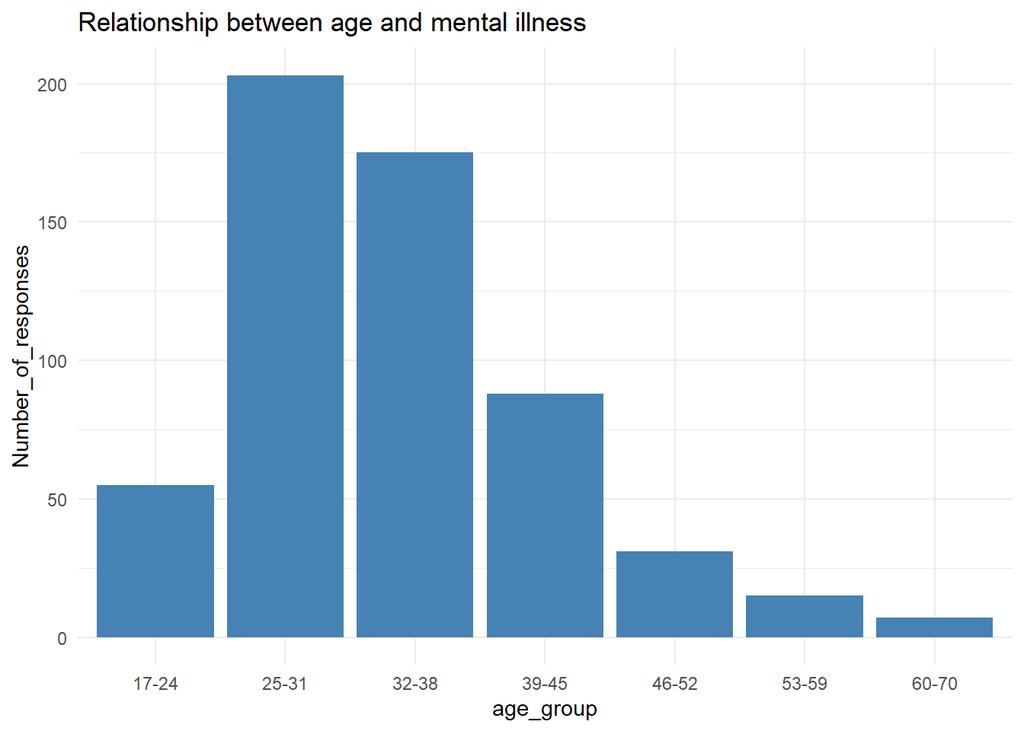

```r
library(dplyr)

#Creating age group range
mental_health_1["age_group"] = cut(mental_health_1$What.is.your.age., c(17, 24, 31, 38, 45,52,59,70), c("17-24", "25-31", "32-38","39-45","46-52", "53-59","60-70"), include.lowest=TRUE)

df4 <- mental_health_1 %>%
  filter(mental_health_1$Do.you.currently.have.a.mental.health.disorder. == "Yes") %>%
  group_by(age_group) %>%
  summarise(Number_of_responses = n())


# barplot for age group
p<-ggplot(data=df4, aes(x=age_group, y=Number_of_responses)) +
  geom_bar(stat="identity",fill="steelblue" ) +
  theme_minimal() + ggtitle("Relationship between age and mental illness")
p
```

```r
# In this plot, age range is generated using cut() function, then aggregated to find the count of people that responded 'Yes' for mental illness and visualized using a bar plot.
```

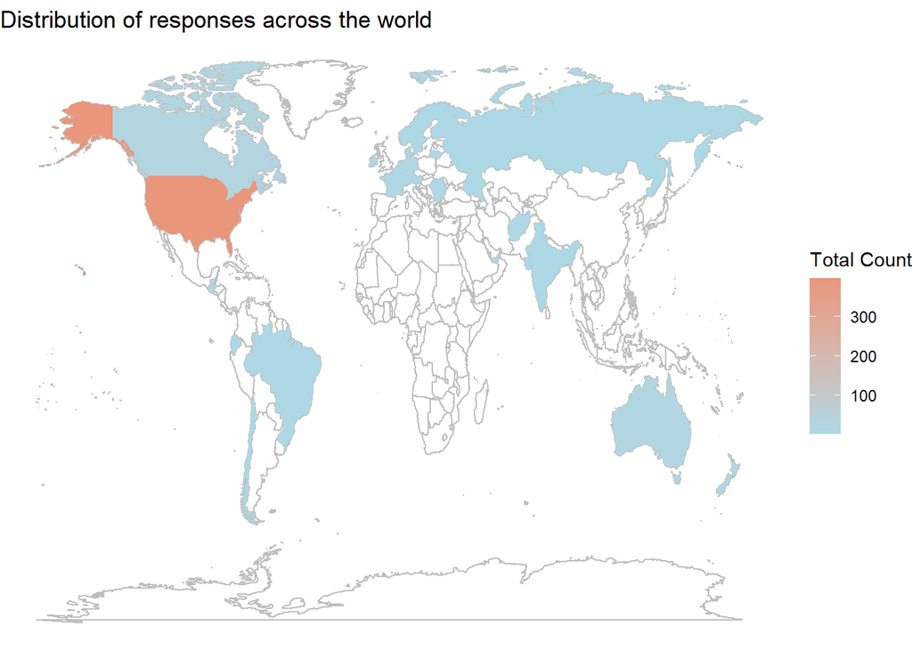

```r
#world-map
df5<- mental_health_1%>%
  filter(Do.you.currently.have.a.mental.health.disorder. == "Yes")%>%
  group_by(What.country.do.you.work.in.)%>%
  summarise(count=n())
df5$What.country.do.you.work.in.[df5$What.country.do.you.work.in. == "United States of America"] <- "USA"

world_map <- map_data("world")

p5<- ggplot(df5) +
  geom_map(
    dat = world_map, map = world_map, aes(map_id = region),
    fill = "white", color = "grey", size = 0.5
  ) +
  geom_map(map = world_map, aes(map_id =What.country.do.you.work.in. , fill = count), size = 0.5) +
  scale_fill_gradient(low = "light blue", high = "dark salmon", name = "Total Count") +
  expand_limits(x = world_map$long, y = world_map$lat) + theme_classic() + ggtitle("Distribution of responses across the world")+ labs(y=" ", x = " ")+theme_void()
p5
```

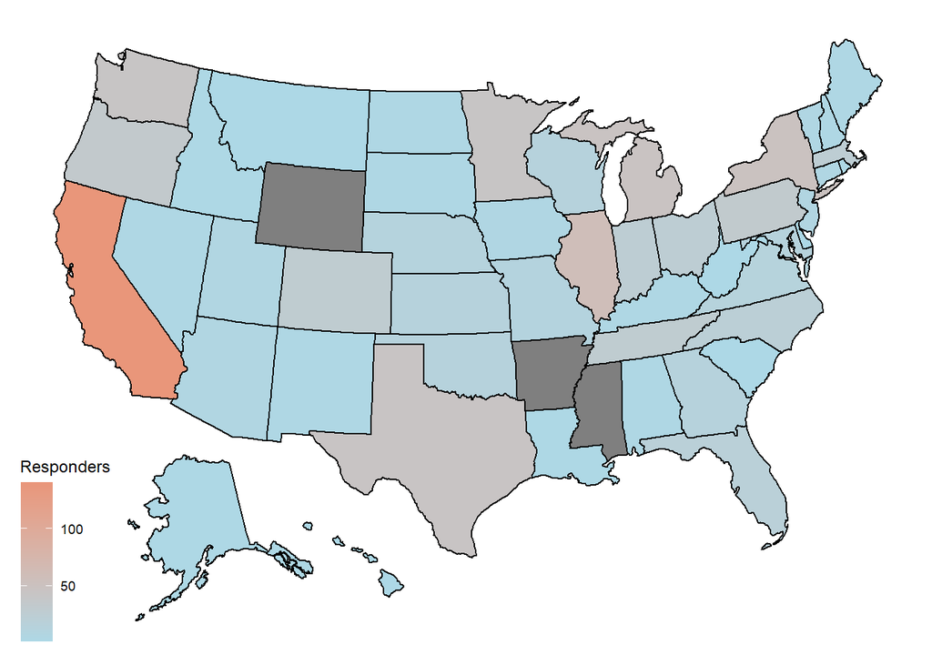

```r
# In this plot, a heat map(world) is produced after aggregating the data based on countries to find the count of people from each country that responded 'Yes' to mental illness

#usmap

state <- levels(mental_health_1$What.US.state.or.territory.do.you.work.in.) %>% as.data.frame()
#nlevels(mental_health_1$What.US.state.or.territory.do.you.work.in.)

state_freq <- as.data.frame(table(mental_health_1$What.US.state.or.territory.do.you.work.in.))
colnames(state_freq) <- c("state","freq")
#as_tibble(state_freq)

p6 <- plot_usmap(data = state_freq, values = "freq",color = "black") +
  scale_fill_continuous(low = "light blue", high = "dark salmon", name = "Responders")
p6
```

```r
# In the above plot, a heat map based on US states is produced after aggregating the data based on number of respondents from each state in US to find the distribution
```

#Theme2 - Employee awareness of mental health help and resources available in their companies. #Q2 - Is there a difference between mental health benefits offered in Technology based companies and non technology based companies

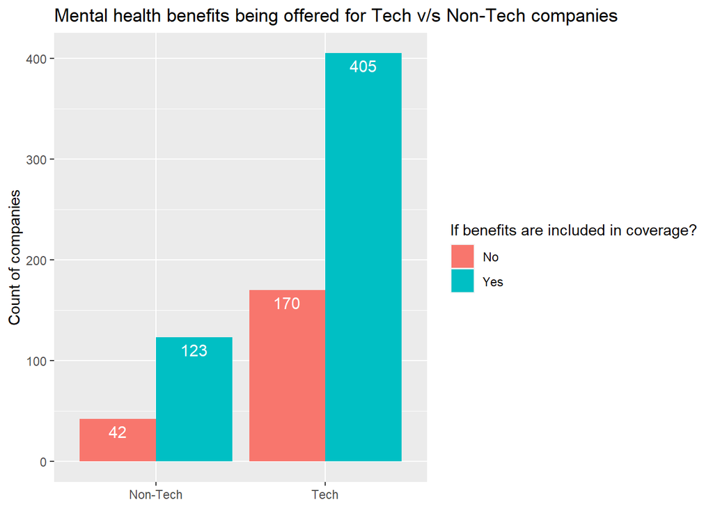

```r
mental_health_tn <- mental_health_1 %>%
  group_by(Tech_company,mental_health_benefits_by_employer_aspart_of_coverage) %>%
  summarise(Count=n()) %>%
  filter(Tech_company %in% c(0,1) &
           mental_health_benefits_by_employer_aspart_of_coverage %in% c("Yes","No"))
mental_health_tn$Tech_company = replace(mental_health_tn$Tech_company,mental_health_tn$Tech_company == 0, "Non-Tech")
mental_health_tn$Tech_company = replace(mental_health_tn$Tech_company,mental_health_tn$Tech_company == 1, "Tech")


ggplot(mental_health_tn,
       aes(x=Tech_company,y=Count,fill=mental_health_benefits_by_employer_aspart_of_coverage)) +
  geom_bar(stat = "identity", position=position_dodge()) +
  geom_text(
    aes(label = Count),
    colour = "white", size = 4,
    vjust = 1.5, position = position_dodge(.9)
  ) +
  theme(axis.title.x=element_blank()) +
  ggtitle("Mental health benefits being offered for Tech v/s Non-Tech companies") +
  ylab("Count of companies") +
  scale_fill_discrete(name = "If benefits are included in coverage?")
```

```r
# In this block, columns that contain employment type(Tech/Non-tech) and insurance coverage of mental illness is grouped to find the count and later fed to the ggplot function to create a grouped bar-chart
```

#Q2 - Is there a relationship between the size of the company and mental illness coverage benefits provided by the company?

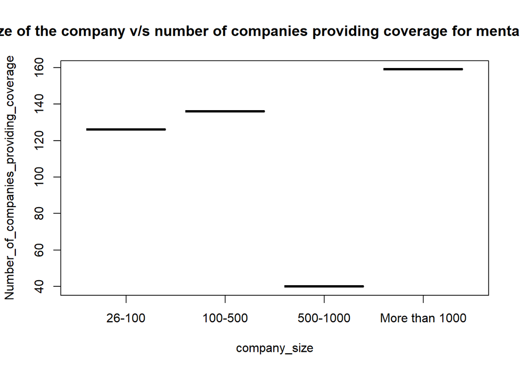

```r
mental_health_2 <- mental_health_1 %>%
  filter(!company_size %in% c("25-Jun","5-Jan")) %>%
  droplevels()

levels(mental_health_2$company_size) <- c("26-100","100-500","500-1000","More than 1000")

c <- mental_health_2 %>%
  group_by(company_size) %>%
  filter(mental_health_benefits_by_employer_aspart_of_coverage == "Yes") %>%
  summarise(Number_of_companies_providing_coverage = n()) %>%
  drop_na()
levels(c$company_size) <- c("26-100","100-500","500-1000","More than 1000")
plot(c)
title(main = "Size of the company v/s number of companies providing coverage for mental illnes")
```

```r
# In this code-block, some cleaning is performed to exclude the incorrect data about company size , then leveled and grouped to find the number of companies that provide coverage for each range and visualized using the plo() function
```

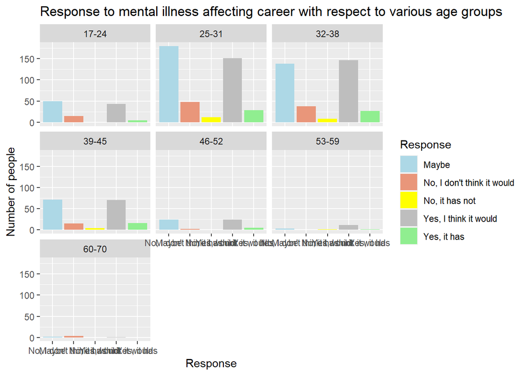

```r
df11 <- mental_health_1 %>%
  filter(self_employed == "Employed in a Company") %>%
  group_by(age_group, Do.you.feel.that.being.identified.as.a.person.with.a.mental.health.issue.would.hurt.your.career.) %>%
  summarise( count_a = n()) %>%
  na.omit()



ggplot(df11, aes(x= Do.you.feel.that.being.identified.as.a.person.with.a.mental.health.issue.would.hurt.your.career., y = count_a, fill = Do.you.feel.that.being.identified.as.a.person.with.a.mental.health.issue.would.hurt.your.career.)) + geom_bar(stat = "identity") + facet_wrap(~ age_group) +
  scale_fill_manual(name = "Response",values = c("Light blue","dark salmon", "yellow","Grey", "light green")) +
  ggtitle("Response to mental illness affecting career with respect to various age groups") + xlab("Response") + ylab("Number of people")
```

```r
# In this chunk, people who are employed in a company are filtered out ao find the people count based on the age distribution and visualized that data using bar grapgh. Facet_wrap() function is used to separate and display the bar graph for each age group.
```

#Theme3 - The Taboo around mental health in technical companies

#Q1- On opening up about mental illness, do employees face unsupportive behaviour from other people in the workspace?

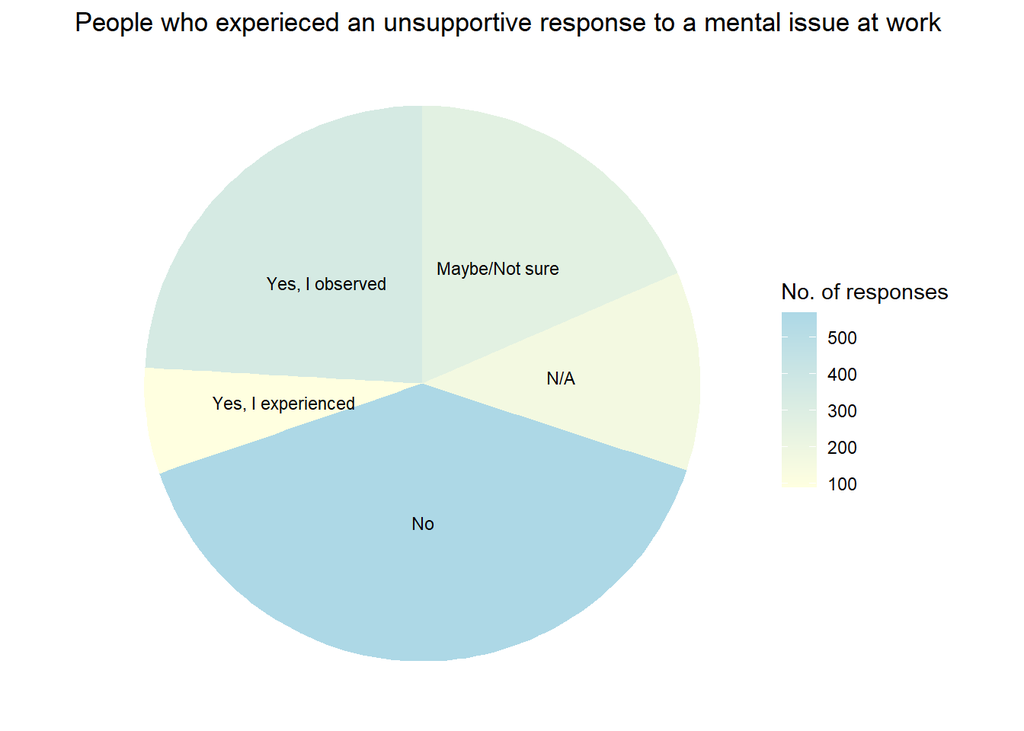

```r
df6 <- mental_health_1 %>%
  group_by(Have.you.observed.or.experienced.an.unsupportive.or.badly.handled.response.to.a.mental.health.issue.in.your.current.or.previous.workplace.) %>%
  summarise(total1 = n())

#pie chart

lbls <- c("Maybe/Not sure", "N/A", "No", "Yes, I experienced", "Yes, I observed")
df6 <- df6 %>%
  arrange(desc(lbls)) %>%
  mutate(prop = total1 / sum(df6$total1) *100) %>%
  mutate(ypos = cumsum(prop)- 0.5*prop )

ggplot(df6, aes(x="lbls", y=total1, fill=total1)) +
  geom_bar(stat="identity") +
  labs(title = "People who experieced an unsupportive response to a mental issue at work")  + geom_text(aes(label = lbls),
            position = position_stack(vjust = 0.5), size = 3) +
  coord_polar(theta = "y")  + scale_fill_continuous(name="No. of responses", low="light yellow", high= "light blue")+

theme_void()
```

```r
# In this part, a pie chart that shows the number of people that had responded to "Have.you.observed.or.experienced.an.unsupportive.or.badly.handled.response.to.a.mental.health.issue.in.your.current.or.previous.workplace." question in the survey. coor_polar is used to produce a pie chart for this data distribution
```

#Q2- Do employers take mental health as seriously as physical health?

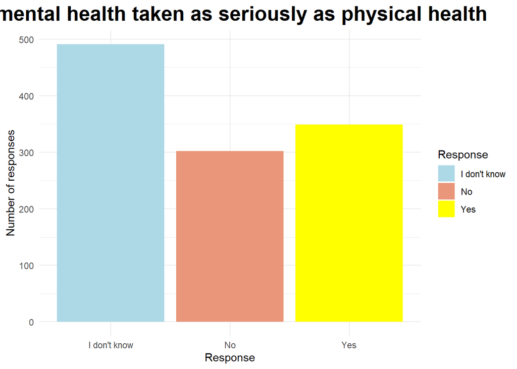

```r
#comparison between bringing up a physical health issue v/s bringing up a mental health issue
df7 <- mental_health_1 %>%
  group_by(does_employer_take_mental_health_as_seriously_as_physical_health) %>%
  summarise(count_p = n()) %>% na.omit()

ggplot(df7, aes(fill=does_employer_take_mental_health_as_seriously_as_physical_health, y=count_p, x=does_employer_take_mental_health_as_seriously_as_physical_health)) +
  geom_bar(position='dodge', stat='identity') +
  theme_minimal() +
  labs(x='Response', y='Number of responses', title='Is mental health taken as seriously as physical health') +
  theme(plot.title = element_text(hjust=0.5, size=20, face='bold')) +
  scale_fill_manual('Response', values=c('Light Blue', 'Darksalmon', 'Yellow'))
```

```r
# In this chunk, people responded to "does_employer_take_mental_health_as_seriously_as_physical_health" question is considered. Data after summarizing is passed to ggplot to create a bar plot and several aesthetic functions are aapplied to improve the visualization
```

#Q3 - In the opinion of employees, do they feel that they would face negative consequences on discussing mental health issues with their employer?

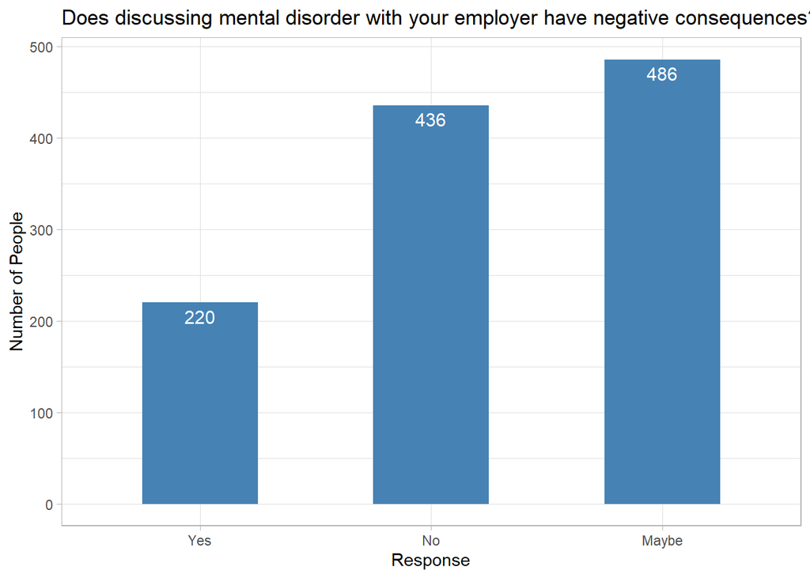

```r
#reactions to menatl health v/s physical health

df8 <- mental_health_1 %>%
  group_by(discussing_mental_disorder_with_employer_have_negetive_consequences) %>%
  summarise(count_m = n()) %>% na.omit()

 ggplot(df8, aes(x=reorder(discussing_mental_disorder_with_employer_have_negetive_consequences, count_m), y=count_m)) +
  geom_bar(stat='identity', fill="steelblue", width = 0.5) +
   theme_light() + geom_text(
    aes(label = count_m),
    colour = "white", size = 4,
    vjust = 1.5, position = position_dodge(.9)
  ) +
  ggtitle("Does discussing mental disorder with your employer have negative consequences?") +
  xlab("Response") +
  ylab("Number of People")
```

```r
 # In this code chunk, responses of the people who thought discussing mentall illness would produce negative consequences are aggregated to find the count and later visualized using a bar plot
```

#Q4 - Do different genders, people from different designation have different opinions about sharing the mental illness with their supervisors?

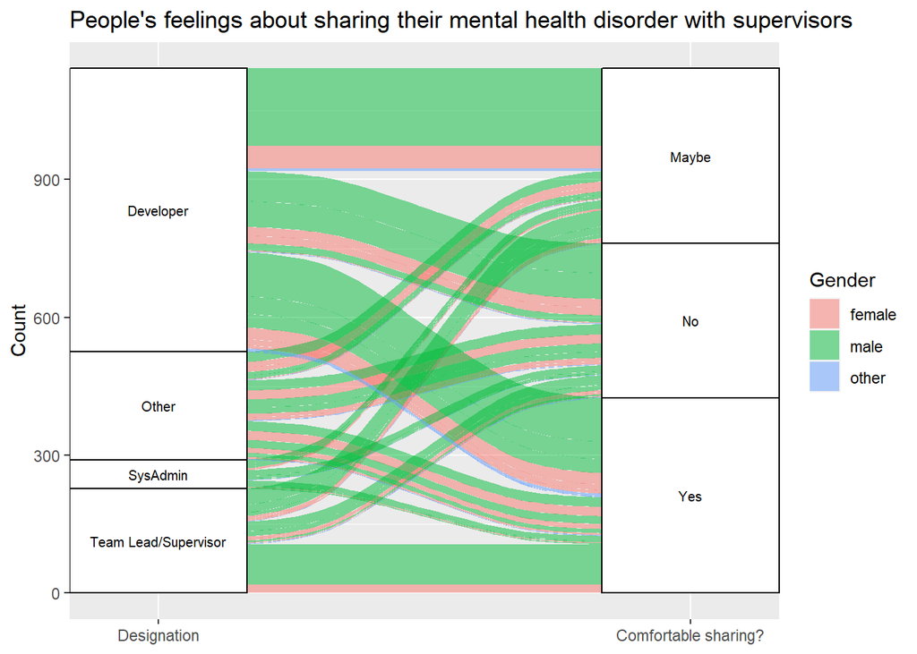

```r
mental_health_allu <- mental_health_1 %>%
  select(What.is.your.gender., Do.you.work.remotely.,
         Which.of.the.following.best.describes.your.work.position., comfortable_sharing_mental_health_disorder_with_supervisors)

for (i in 1:nrow(mental_health_allu))
  if (str_detect(mental_health_allu$Which.of.the.following.best.describes.your.work.position.[i],"Team Lead|Supervisor") == TRUE) {
    mental_health_allu$Which.of.the.following.best.describes.your.work.position.[i] = "Team Lead/Supervisor"
  } else if (str_detect(mental_health_allu$Which.of.the.following.best.describes.your.work.position.[i],"Developer") == TRUE) {
    mental_health_allu$Which.of.the.following.best.describes.your.work.position.[i] = "Developer"
  } else if (str_detect(mental_health_allu$Which.of.the.following.best.describes.your.work.position.[i],"SysAdmin") == TRUE) {
    mental_health_allu$Which.of.the.following.best.describes.your.work.position.[i] = "SysAdmin"
  } else  {
    mental_health_allu$Which.of.the.following.best.describes.your.work.position.[i] = "Other"
  }

mhc<- mental_health_allu %>%
  group_by_all() %>%
  summarise(Count=n()) %>%
  arrange(desc(Count)) %>%
  drop_na() %>%
  rename(Designation = Which.of.the.following.best.describes.your.work.position.,
         Work_mode = Do.you.work.remotely.,
         Gender = What.is.your.gender.)


ggplot(mhc,
       aes(y = `Count`, axis1 = `Designation`, axis2 = comfortable_sharing_mental_health_disorder_with_supervisors)) +
  scale_x_discrete(limits = c("Designation", "Comfortable sharing?"), expand = c(.05, .05)) +
  geom_alluvium(aes(fill = Gender)) +
  geom_stratum() +
  geom_text(stat = "stratum", aes(label = after_stat(stratum)),size=2.7) +
  ggtitle("People's feelings about sharing their mental health disorder with supervisors")
```

```r
# In this plot, columns containing gender, Designation are represented using an alluvial chart based on their responses to sharing their mental health status with supervisors
```

#Q5 - Do different genders, people from different designation have different opinions about sharing the mental illness with their peers/co-workers?

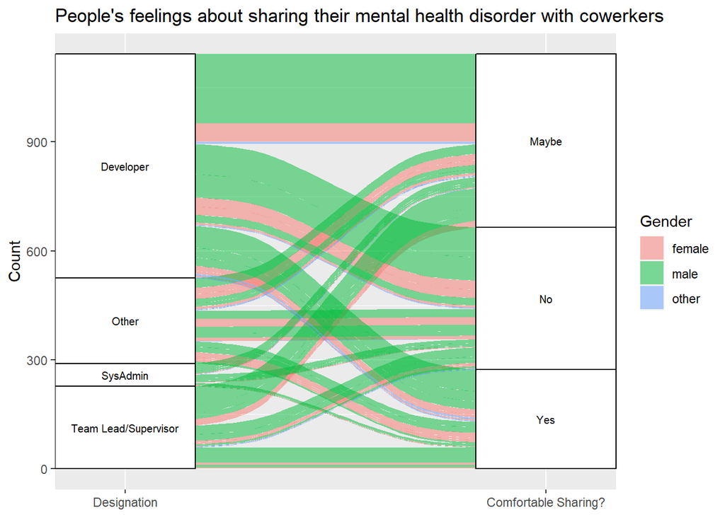

```r
mental_health_allu <- mental_health_1 %>%
  select(What.is.your.gender., Do.you.work.remotely.,
         Which.of.the.following.best.describes.your.work.position., comfortable_sharing_mental_health_disorder_with_coworkers)

for (i in 1:nrow(mental_health_allu))
  if (str_detect(mental_health_allu$Which.of.the.following.best.describes.your.work.position.[i],"Team Lead|Supervisor") == TRUE) {
    mental_health_allu$Which.of.the.following.best.describes.your.work.position.[i] = "Team Lead/Supervisor"
  } else if (str_detect(mental_health_allu$Which.of.the.following.best.describes.your.work.position.[i],"Developer") == TRUE) {
    mental_health_allu$Which.of.the.following.best.describes.your.work.position.[i] = "Developer"
  } else if (str_detect(mental_health_allu$Which.of.the.following.best.describes.your.work.position.[i],"SysAdmin") == TRUE) {
    mental_health_allu$Which.of.the.following.best.describes.your.work.position.[i] = "SysAdmin"
  } else  {
    mental_health_allu$Which.of.the.following.best.describes.your.work.position.[i] = "Other"
  }

mhc<- mental_health_allu %>%
  group_by_all() %>%
  summarise(Count=n()) %>%
  arrange(desc(Count)) %>%
  drop_na() %>%
  rename(Designation = Which.of.the.following.best.describes.your.work.position.,
         Work_mode = Do.you.work.remotely.,
         Gender = What.is.your.gender.)


ggplot(mhc,
       aes(y = `Count`, axis1 = `Designation`, axis2 = comfortable_sharing_mental_health_disorder_with_coworkers)) +
  scale_x_discrete(limits = c("Designation", "Comfortable Sharing?"), expand = c(.05, .05)) +
  geom_alluvium(aes(fill = Gender)) +
  geom_stratum() +
  geom_text(stat = "stratum", aes(label = after_stat(stratum)),size=2.7) +
  ggtitle("People's feelings about sharing their mental health disorder with cowerkers")
```

```r
# In this plot, columns containing gender, Designation are represented using an alluvial chart based on their responses to sharing their mental health status with peers/co-workers
```